# Cleaning and Preparing Data

Author

Jamal Rogers

## 1. Introduction

In applied data science, **cleaning and preparing data** is often the most time-consuming but critical step. Raw data is rarely perfect: it may have **missing values**, **inconsistent formatting**, or require **transformation** to make it useful for modeling and analysis.

In this lesson, we’ll cover:

- Handling missing and incomplete data
- Formatting and transforming data
- Practical implementation using **`polars`** (for data manipulation) and **`plotnine`** (for visualization)

## 2. Handling Missing and Incomplete Data

### Why is it important?

Missing or incomplete data can:

- Bias results if ignored
- Reduce the accuracy of machine learning models
- Cause errors during computation

### Common Strategies

1. **Remove missing values** – drop rows/columns with NaN values.
2. **Impute missing values** – replace missing values with:

   > Mean, median, or mode (for numerical data)

   > Constant values (e.g., “Unknown” for categorical)
3. **Predict missing values** – use models to fill in gaps (advanced).

### Example in Python (using `polars`)

```python
import polars as pl

# Sample dataset with missing values
df = pl.DataFrame({
    "student": ["Alice", "Bob", "Charlie", "David"],
    "score": [85, None, 90, None],
    "course": ["Math", "Math", "Science", None]
})

print("Original DataFrame:")
print(df)

# Drop rows with missing values
df_drop = df.drop_nulls()
print("\nAfter dropping missing values:")
print(df_drop)

# Fill missing numerical values with mean
df_fill_mean = df.with_columns(
    df["score"].fill_null(df["score"].mean())
)

# Fill missing categorical values with a constant
df_fill_course = df.with_columns(
    df["course"].fill_null("Unknown")
)

print("\nAfter filling missing values:")
print(df_fill_mean)
print(df_fill_course)
```

```
Original DataFrame:
shape: (4, 3)
┌─────────┬───────┬─────────┐
│ student ┆ score ┆ course  │
│ ---     ┆ ---   ┆ ---     │
│ str     ┆ i64   ┆ str     │
╞═════════╪═══════╪═════════╡
│ Alice   ┆ 85    ┆ Math    │
│ Bob     ┆ null  ┆ Math    │
│ Charlie ┆ 90    ┆ Science │
│ David   ┆ null  ┆ null    │
└─────────┴───────┴─────────┘

After dropping missing values:
shape: (2, 3)
┌─────────┬───────┬─────────┐
│ student ┆ score ┆ course  │
│ ---     ┆ ---   ┆ ---     │
│ str     ┆ i64   ┆ str     │
╞═════════╪═══════╪═════════╡
│ Alice   ┆ 85    ┆ Math    │
│ Charlie ┆ 90    ┆ Science │
└─────────┴───────┴─────────┘

After filling missing values:
shape: (4, 3)
┌─────────┬───────┬─────────┐
│ student ┆ score ┆ course  │
│ ---     ┆ ---   ┆ ---     │
│ str     ┆ f64   ┆ str     │
╞═════════╪═══════╪═════════╡
│ Alice   ┆ 85.0  ┆ Math    │
│ Bob     ┆ 87.5  ┆ Math    │
│ Charlie ┆ 90.0  ┆ Science │
│ David   ┆ 87.5  ┆ null    │
└─────────┴───────┴─────────┘
shape: (4, 3)
┌─────────┬───────┬─────────┐
│ student ┆ score ┆ course  │
│ ---     ┆ ---   ┆ ---     │
│ str     ┆ i64   ┆ str     │
╞═════════╪═══════╪═════════╡
│ Alice   ┆ 85    ┆ Math    │
│ Bob     ┆ null  ┆ Math    │
│ Charlie ┆ 90    ┆ Science │
│ David   ┆ null  ┆ Unknown │
└─────────┴───────┴─────────┘
```

## 3. Formatting Data

### Why format?

Datasets often come with inconsistent formats:

- Dates stored as strings
- Numbers stored as text
- Categorical values with inconsistent capitalization

### Example in Python

```python
# Create a dataset with formatting issues
df_format = pl.DataFrame({
    "date": ["2025-01-01", "2025/01/02", "01-03-2025"],
    "grade": ["85", "90", "88"],
    "course": ["math", "Math", "MATH"]
})

# Convert date to proper format
df_format = df_format.with_columns(
    pl.col("date").str.strptime(pl.Date, "%Y-%m-%d", strict=False)
)

# Convert grade to integer
df_format = df_format.with_columns(
    pl.col("grade").cast(pl.Int32)
)

# Standardize course names
df_format = df_format.with_columns(
    pl.col("course").str.to_lowercase()
)

print(df_format)
```

```
shape: (3, 3)
┌────────────┬───────┬────────┐
│ date       ┆ grade ┆ course │
│ ---        ┆ ---   ┆ ---    │
│ date       ┆ i32   ┆ str    │
╞════════════╪═══════╪════════╡
│ 2025-01-01 ┆ 85    ┆ math   │
│ null       ┆ 90    ┆ math   │
│ null       ┆ 88    ┆ math   │
└────────────┴───────┴────────┘
```

## 4. Transforming Data

### Why transform?

Transformation helps in:

- Normalizing values for comparison
- Creating new features
- Aggregating data for summaries

### Example in Python

```python
df_trans = pl.DataFrame({
    "student": ["Alice", "Bob", "Charlie", "David"],
    "math_score": [85, 70, 90, 60],
    "science_score": [88, 75, 85, 70]
})

# Create new column: average score
df_trans = df_trans.with_columns(
    ((pl.col("math_score") + pl.col("science_score")) / 2).alias("avg_score")
)

# Normalize scores (0–1 scale)
df_trans = df_trans.with_columns(
    (pl.col("avg_score") / pl.col("avg_score").max()).alias("normalized_score")
)

print(df_trans)
```

```
shape: (4, 5)
┌─────────┬────────────┬───────────────┬───────────┬──────────────────┐
│ student ┆ math_score ┆ science_score ┆ avg_score ┆ normalized_score │
│ ---     ┆ ---        ┆ ---           ┆ ---       ┆ ---              │
│ str     ┆ i64        ┆ i64           ┆ f64       ┆ f64              │
╞═════════╪════════════╪═══════════════╪═══════════╪══════════════════╡
│ Alice   ┆ 85         ┆ 88            ┆ 86.5      ┆ 0.988571         │
│ Bob     ┆ 70         ┆ 75            ┆ 72.5      ┆ 0.828571         │
│ Charlie ┆ 90         ┆ 85            ┆ 87.5      ┆ 1.0              │
│ David   ┆ 60         ┆ 70            ┆ 65.0      ┆ 0.742857         │
└─────────┴────────────┴───────────────┴───────────┴──────────────────┘
```

## 5. Visualizing Cleaned and Transformed Data with plotnine

Visualization helps confirm whether cleaning and transformation were successful.

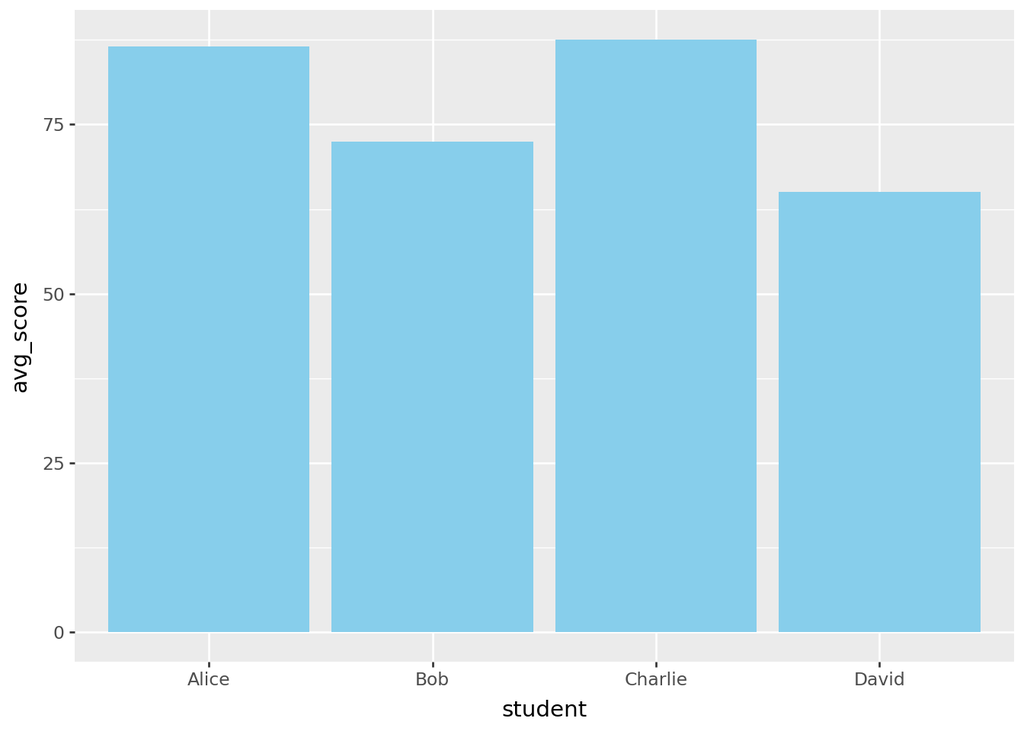

```python
from plotnine import ggplot, aes, geom_bar, geom_point

# Bar chart of average scores by student
ggplot(df_trans.to_pandas(), aes(x="student", y="avg_score")) +\
    geom_bar(stat="identity", fill="skyblue")
```

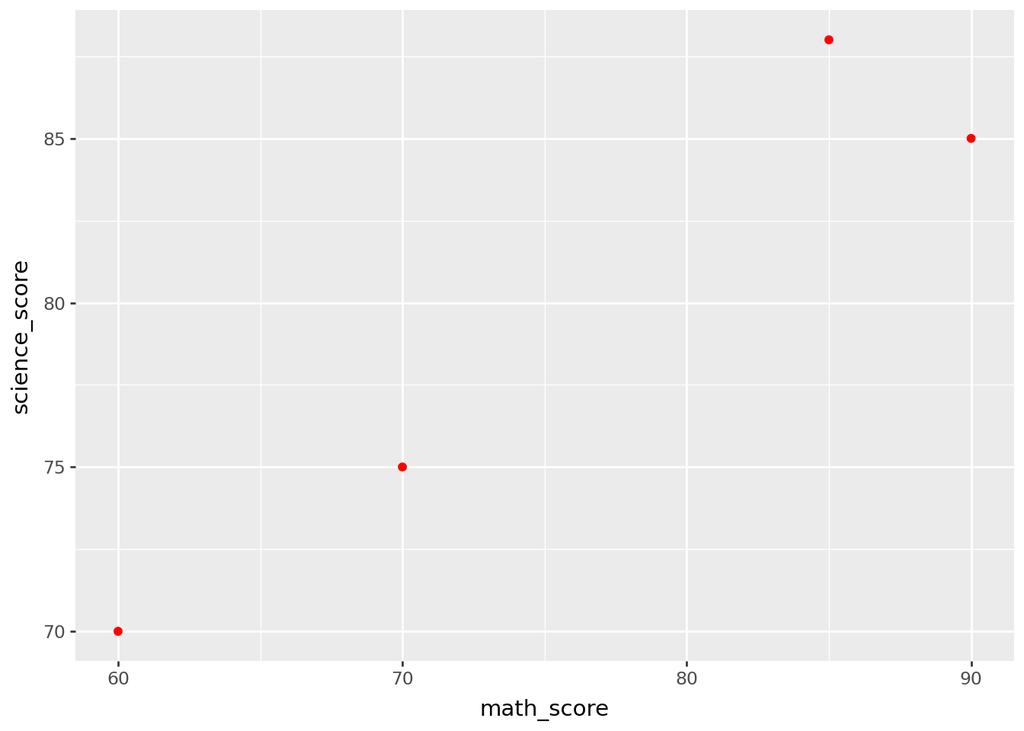

```python
# Scatter plot of math vs science scores
ggplot(df_trans.to_pandas(), aes(x="math_score", y="science_score")) +\
    geom_point(color="red")
```

## 6. Summary

- **Handling missing data** prevents bias and ensures valid results.
- **Formatting data** standardizes representations for consistency.
- **Transforming data** creates new insights and features for analysis.
- **Visualization** with `plotnine` validates our data cleaning efforts.

## Wrap-Up

By mastering these techniques, you ensure your datasets are **reliable, consistent, and ready for analysis or modeling**.

## Exercise 1: Handling Missing Data

```python
import polars as pl

df1 = pl.DataFrame({
    "student": ["Alice", "Bob", "Charlie", "David", "Eva"],
    "math_score": [85, None, 90, 72, None],
    "science_score": [88, 75, None, None, 80],
    "course": ["Math", "Math", "Science", None, "Science"]
})

print(df1)
```

```
shape: (5, 4)
┌─────────┬────────────┬───────────────┬─────────┐
│ student ┆ math_score ┆ science_score ┆ course  │
│ ---     ┆ ---        ┆ ---           ┆ ---     │
│ str     ┆ i64        ┆ i64           ┆ str     │
╞═════════╪════════════╪═══════════════╪═════════╡
│ Alice   ┆ 85         ┆ 88            ┆ Math    │
│ Bob     ┆ null       ┆ 75            ┆ Math    │
│ Charlie ┆ 90         ┆ null          ┆ Science │
│ David   ┆ 72         ┆ null          ┆ null    │
│ Eva     ┆ null       ┆ 80            ┆ Science │
└─────────┴────────────┴───────────────┴─────────┘
```

### Tasks

1. Drop rows where *any* value is missing.
2. Fill missing `math_score` with the **mean** of the column.
3. Fill missing `science_score` with the **median** of the column.
4. Fill missing `course` with `"Unknown"`.

### Expected Skill

Students should learn how to **decide on strategies** for handling missing values.

## Exercise 2: Formatting Data

```python
df2 = pl.DataFrame({
    "id": ["001", "002", "003", "004"],
    "date": ["2025-01-01", "2025/01/02", "01-03-2025", "2025.01.04"],
    "grade": ["85", "90", "88", "92"],
    "course": ["math", "Math", "MATH", "sci"]
})

print(df2)
```

```
shape: (4, 4)
┌─────┬────────────┬───────┬────────┐
│ id  ┆ date       ┆ grade ┆ course │
│ --- ┆ ---        ┆ ---   ┆ ---    │
│ str ┆ str        ┆ str   ┆ str    │
╞═════╪════════════╪═══════╪════════╡
│ 001 ┆ 2025-01-01 ┆ 85    ┆ math   │
│ 002 ┆ 2025/01/02 ┆ 90    ┆ Math   │
│ 003 ┆ 01-03-2025 ┆ 88    ┆ MATH   │
│ 004 ┆ 2025.01.04 ┆ 92    ┆ sci    │
└─────┴────────────┴───────┴────────┘
```

### Tasks

1. Convert `id` to integers.
2. Convert `date` into a proper date format.
3. Convert `grade` into integers.
4. Standardize `course` names so `"math"`, `"Math"`, and `"MATH"` all become `"math"`.

### Expected Skill

Students practice **data type conversion** and **standardization**.

## Exercise 3: Transforming Data

```python
df3 = pl.DataFrame({
    "student": ["Alice", "Bob", "Charlie", "David"],
    "math_score": [85, 70, 90, 60],
    "science_score": [88, 75, 85, 70],
    "english_score": [82, 65, 78, 72]
})

print(df3)
```

```
shape: (4, 4)
┌─────────┬────────────┬───────────────┬───────────────┐
│ student ┆ math_score ┆ science_score ┆ english_score │
│ ---     ┆ ---        ┆ ---           ┆ ---           │
│ str     ┆ i64        ┆ i64           ┆ i64           │
╞═════════╪════════════╪═══════════════╪═══════════════╡
│ Alice   ┆ 85         ┆ 88            ┆ 82            │
│ Bob     ┆ 70         ┆ 75            ┆ 65            │
│ Charlie ┆ 90         ┆ 85            ┆ 78            │
│ David   ┆ 60         ┆ 70            ┆ 72            │
└─────────┴────────────┴───────────────┴───────────────┘
```

### Tasks

1. Create a new column `avg_score` as the average of the three subjects.
2. Create a normalized version of `avg_score` between 0–1
3. Create a new categorical column `status`:

```
`"Pass"` if `avg_score >= 75`

`"Fail"` otherwise
```

### Expected Skill

Students learn **feature engineering** and **scaling/normalization**.

## Exercise 4: Visualization with Cleaned Data

**Use the cleaned `df3` from Exercise 3.**

### Tasks

1. Create a bar chart of average scores by student.
2. Create a scatter plot comparing `math_score` and `science_score`.
3. Create a bar chart showing the number of students who `"Pass"` vs `"Fail"`.

*“Every line of code you write, every formula you solve, and every page you read is a step toward building the future only you can create.”*

- The Data Samurai

[figure not shown]